# BCVA data comparison between Bayesian and frequentist MMRMs

09/07/2024

# About

This vignette uses the `bcva_data` dataset from the `mmrm` package to compare a Bayesian MMRM fit, obtained by `brms.mmrm::brm_model()`, and a frequentist MMRM fit, obtained by `mmrm::mmrm()`. An overview of parameter estimates and differences by type of MMRM is given in the summary (Tables 4 and 5) at the end.

# 1 Prerequisites

This comparison workflow requires the following packages.

```r
> packages <- c(
+   "dplyr",
+   "tidyr",
+   "ggplot2",
+   "gt",
+   "gtsummary",
+   "purrr",
+   "parallel",
+   "brms.mmrm",
+   "mmrm",
+   "posterior"
+ )
> invisible(lapply(packages, library, character.only = TRUE))
```

We set a seed for the random number generator to ensure statistical reproducibility.

```r
> set.seed(123L)
```

# 2 Data

## 2.1 Pre-processing

This analysis exercise uses the `bcva_data` dataset contained in the `mmrm` package:

```r
> data(bcva_data, package = "mmrm")
```

According to https://openpharma.github.io/mmrm/latest-tag/articles/mmrm_review_methods.html:

> The BCVA dataset contains data from a randomized longitudinal ophthalmology trial evaluating the change in baseline corrected visual acuity (BCVA) over the course of 10 visits. BCVA corresponds to the number of letters read from a visual acuity chart.

- `USUBJID` (subject ID)
- `AVISIT` (visit number, factor)
- `VISITN` (visit number, numeric)
- `ARMCD` (treatment, `TRT` or `CTL`)
- `RACE` (3-category race)
- `BCVA_BL` (BCVA at baseline)
- `BCVA_CHG` (BCVA change from baseline, primary endpoint for the analysis)

The rest of the pre-processing steps create factors for the study arm and visit and apply the usual checking and standardization steps of `brms.mmrm::brm_data()`.

```r
> bcva_data <- bcva_data |>
+   mutate(AVISIT = gsub("VIS0*", "VIS", as.character(AVISIT))) |>
+   brm_data(
+     outcome = "BCVA_CHG",
+     group = "ARMCD",
+     time = "AVISIT",
+     patient = "USUBJID",
+     baseline = "BCVA_BL",
+     reference_group = "CTL",
+     covariates = "RACE"
+   ) |>
+   brm_data_chronologize(order = "VISITN")
```

The following table shows the first rows of the dataset.

```r
> head(bcva_data) |>
+   gt() |>
+   tab_caption(caption = md("Table 1. First rows of the pre-processed `bcva_data` dataset."))
```

Table 1. First rows of the pre-processed `bcva_data` dataset.

| USUBJID | AVISIT | VISITN | ARMCD | RACE | BCVA_BL | BCVA_CHG |
| --- | --- | --- | --- | --- | --- | --- |
| 3 | VIS1 | 1 | CTL | Asian | 71.70881 | 5.058546 |
| 3 | VIS10 | 10 | CTL | Asian | 71.70881 | 10.152565 |
| 3 | VIS2 | 2 | CTL | Asian | 71.70881 | 4.018582 |
| 3 | VIS3 | 3 | CTL | Asian | 71.70881 | 3.572535 |
| 3 | VIS4 | 4 | CTL | Asian | 71.70881 | 4.822669 |
| 3 | VIS5 | 5 | CTL | Asian | 71.70881 | 7.348768 |

## 2.2 Descriptive statistics

Table of baseline characteristics:

```r
> bcva_data |>
+   select(ARMCD, USUBJID, RACE, BCVA_BL) |>
+   distinct() |>
+   select(-USUBJID) |>
+   tbl_summary(
+     by = c(ARMCD),
+     statistic = list(
+       all_continuous() ~ "{mean} ({sd})",
+       all_categorical() ~ "{n} / {N} ({p}%)"
+     )
+   ) |>
+   modify_caption("Table 2. Baseline characteristics.")
```

Table 2. Baseline characteristics.

| **Characteristic** | **CTL** N = 494<sup>1</sup> | **TRT** N = 506<sup>1</sup> |
| --- | --- | --- |
| RACE |  |  |
| Asian | 151 / 494 (31%) | 146 / 506 (29%) |
| Black | 149 / 494 (30%) | 168 / 506 (33%) |
| White | 194 / 494 (39%) | 192 / 506 (38%) |
| BCVA_BL | 75 (10) | 75 (10) |

<sup>1</sup> n / N (%); Mean (SD)

Table of change from baseline in BCVA over 52 weeks:

```r
> bcva_data |>
+   pull(AVISIT) |>
+   unique() |>
+   sort() |>
+   purrr::map(
+     .f = ~ bcva_data |>
+       filter(AVISIT %in% .x) |>
+       tbl_summary(
+         by = ARMCD,
+         include = BCVA_CHG,
+         type = BCVA_CHG ~ "continuous2",
+         statistic = BCVA_CHG ~ c(
+           "{mean} ({sd})",
+           "{median} ({p25}, {p75})",
+           "{min}, {max}"
+         ),
+         label = list(BCVA_CHG = paste("Visit ", .x))
+       )
+   ) |>
+   tbl_stack(quiet = TRUE) |>
+   modify_caption("Table 3. Change from baseline.")
```

Table 3. Change from baseline.

| **Characteristic** | **CTL** N = 494 | **TRT** N = 506 |
| --- | --- | --- |
| Visit VIS1 |  |  |
| Mean (SD) | 5.32 (1.23) | 5.86 (1.33) |
| Median (Q1, Q3) | 5.34 (4.51, 6.17) | 5.86 (4.98, 6.81) |
| Min, Max | 1.83, 9.02 | 2.28, 10.30 |
| Unknown | 12 | 5 |
| Visit VIS2 |  |  |
| Mean (SD) | 5.59 (1.49) | 6.33 (1.45) |
| Median (Q1, Q3) | 5.53 (4.64, 6.47) | 6.36 (5.34, 7.31) |
| Min, Max | 0.29, 10.15 | 2.35, 10.75 |
| Unknown | 13 | 7 |
| Visit VIS3 |  |  |
| Mean (SD) | 5.79 (1.61) | 6.79 (1.71) |
| Median (Q1, Q3) | 5.73 (4.64, 6.91) | 6.82 (5.66, 7.93) |
| Min, Max | 1.53, 11.46 | 1.13, 11.49 |
| Unknown | 23 | 17 |
| Visit VIS4 |  |  |
| Mean (SD) | 6.18 (1.73) | 7.29 (1.82) |
| Median (Q1, Q3) | 6.14 (5.05, 7.41) | 7.24 (6.05, 8.54) |
| Min, Max | 0.45, 11.49 | 2.07, 11.47 |
| Unknown | 36 | 18 |
| Visit VIS5 |  |  |
| Mean (SD) | 6.28 (1.97) | 7.68 (1.94) |
| Median (Q1, Q3) | 6.18 (4.96, 7.71) | 7.75 (6.48, 8.95) |
| Min, Max | 0.87, 11.53 | 2.24, 14.10 |
| Unknown | 40 | 35 |
| Visit VIS6 |  |  |
| Mean (SD) | 6.69 (1.97) | 8.31 (1.98) |
| Median (Q1, Q3) | 6.64 (5.26, 8.14) | 8.29 (6.92, 9.74) |
| Min, Max | 1.35, 12.95 | 1.93, 14.38 |
| Unknown | 84 | 48 |
| Visit VIS7 |  |  |
| Mean (SD) | 6.78 (2.09) | 8.78 (2.11) |
| Median (Q1, Q3) | 6.91 (5.46, 8.29) | 8.67 (7.44, 10.26) |
| Min, Max | -1.54, 11.99 | 3.21, 14.36 |
| Unknown | 106 | 78 |
| Visit VIS8 |  |  |
| Mean (SD) | 7.08 (2.25) | 9.40 (2.26) |
| Median (Q1, Q3) | 7.08 (5.55, 8.68) | 9.35 (7.96, 10.86) |
| Min, Max | 0.97, 13.71 | 2.28, 15.95 |
| Unknown | 123 | 86 |
| Visit VIS9 |  |  |
| Mean (SD) | 7.39 (2.33) | 10.01 (2.50) |
| Median (Q1, Q3) | 7.47 (5.76, 9.05) | 10.01 (8.19, 11.74) |
| Min, Max | 0.04, 14.61 | 4.22, 18.09 |
| Unknown | 167 | 114 |
| Visit VIS10 |  |  |
| Mean (SD) | 7.49 (2.58) | 10.59 (2.36) |
| Median (Q1, Q3) | 7.40 (5.73, 9.01) | 10.71 (9.03, 12.25) |
| Min, Max | -0.08, 15.75 | 3.24, 16.40 |
| Unknown | 213 | 170 |

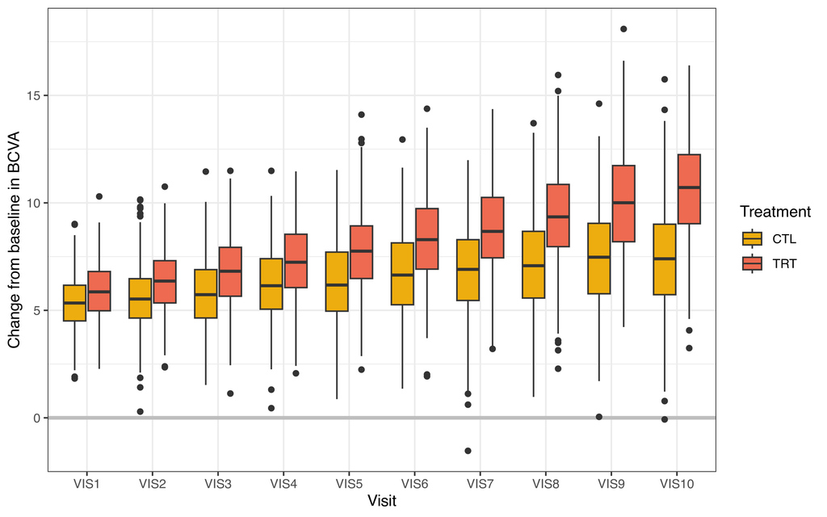

```r
> bcva_data |>
+   group_by(ARMCD) |>
+   ggplot(aes(x = AVISIT, y = BCVA_CHG, fill = factor(ARMCD))) +
+   geom_hline(yintercept = 0, col = "grey", linewidth = 1.2) +
+   geom_boxplot(na.rm = TRUE) +
+   labs(
+     x = "Visit",
+     y = "Change from baseline in BCVA",
+     fill = "Treatment"
+   ) +
+   scale_fill_manual(values = c("darkgoldenrod2", "coral2")) +
+   theme_bw()
```

# 3 Fitting MMRMs

## 3.1 Bayesian model

The formula for the Bayesian model includes additive effects for baseline, study visit, race, and study-arm-by-visit interaction.

```r
> b_mmrm_formula <- brm_formula(
+   data = bcva_data,
+   intercept = TRUE,
+   baseline = TRUE,
+   group = FALSE,
+   time = TRUE,
+   baseline_time = FALSE,
+   group_time = TRUE,
+   correlation = "unstructured"
+ )
> print(b_mmrm_formula)
```

```
#> BCVA_CHG ~ BCVA_BL + ARMCD:AVISIT + AVISIT + RACE + unstr(time = AVISIT, gr = USUBJID)
#> sigma ~ 0 + AVISIT
```

We fit the model using `brms.mmrm::brm_model()`. The computation takes several minutes because of the size of the dataset. To ensure a good basis of comparison with the frequentist model, we put an extremely diffuse prior on the intercept. The parameters already have diffuse flexible priors by default.

```r
> b_mmrm_fit <- brm_model(
+   data = filter(bcva_data, !is.na(BCVA_CHG)),
+   formula = b_mmrm_formula,
+   prior = brms::prior(class = "Intercept", prior = "student_t(3, 0, 1000)"),
+   iter = 10000,
+   warmup = 2000,
+   chains = 4,
+   cores = 4,
+   seed = 1,
+   refresh = 0
+ )
```

Here is a posterior summary of model parameters, including fixed effects and pairwise correlation among visits within patients.

```r
> summary(b_mmrm_fit)
```

```
#>  Family: gaussian
#>   Links: mu = identity; sigma = log
#> Formula: BCVA_CHG ~ BCVA_BL + ARMCD:AVISIT + AVISIT + RACE + unstr(time = AVISIT, gr = USUBJID)
#>          sigma ~ 0 + AVISIT
#>    Data: data[!is.na(data[[attr(data, "brm_outcome")]]), ] (Number of observations: 8605)
#>   Draws: 4 chains, each with iter = 10000; warmup = 2000; thin = 1;
#>          total post-warmup draws = 32000
#>
#> Correlation Structures:
#>                     Estimate Est.Error l-95% CI u-95% CI Rhat Bulk_ESS Tail_ESS
#> cortime(VIS1,VIS2)      0.05      0.03    -0.01     0.11 1.00    63561    23159
#> cortime(VIS1,VIS3)      0.31      0.03     0.25     0.36 1.00    70330    25831
#> cortime(VIS2,VIS3)      0.05      0.03    -0.02     0.11 1.00    67715    22226
#> cortime(VIS1,VIS4)      0.21      0.03     0.15     0.27 1.00    46375    28108
#> cortime(VIS2,VIS4)      0.14      0.03     0.07     0.20 1.00    50232    27277
#> cortime(VIS3,VIS4)     -0.01      0.03    -0.07     0.05 1.00    50449    26940
#> cortime(VIS1,VIS5)      0.17      0.03     0.11     0.23 1.00    49366    27023
#> cortime(VIS2,VIS5)      0.12      0.03     0.05     0.18 1.00    53327    28297
#> cortime(VIS3,VIS5)     -0.01      0.03    -0.07     0.06 1.00    52752    26884
#> cortime(VIS4,VIS5)      0.38      0.03     0.32     0.43 1.00    49514    26959
#> cortime(VIS1,VIS6)      0.26      0.03     0.20     0.32 1.00    45483    26765
#> cortime(VIS2,VIS6)      0.20      0.03     0.14     0.27 1.00    48236    27168
#> cortime(VIS3,VIS6)      0.04      0.03    -0.02     0.11 1.00    51506    27189
#> cortime(VIS4,VIS6)      0.40      0.03     0.35     0.46 1.00    48730    25696
#> cortime(VIS5,VIS6)      0.39      0.03     0.34     0.45 1.00    55438    25998
#> cortime(VIS1,VIS7)      0.07      0.04    -0.00     0.13 1.00    66961    24586
#> cortime(VIS2,VIS7)      0.09      0.03     0.02     0.15 1.00    66564    23212
#> cortime(VIS3,VIS7)     -0.00      0.03    -0.07     0.07 1.00    62299    24284
#> cortime(VIS4,VIS7)      0.15      0.03     0.08     0.22 1.00    70101    23346
#> cortime(VIS5,VIS7)      0.19      0.03     0.13     0.26 1.00    71412    24243
#> cortime(VIS6,VIS7)      0.21      0.04     0.14     0.28 1.00    69307    23697
#> cortime(VIS1,VIS8)      0.05      0.04    -0.02     0.12 1.00    70424    22845
#> cortime(VIS2,VIS8)      0.10      0.04     0.03     0.17 1.00    71230    23497
#> cortime(VIS3,VIS8)     -0.03      0.04    -0.10     0.04 1.00    65689    22667
#> cortime(VIS4,VIS8)      0.17      0.03     0.10     0.24 1.00    68079    23681
#> cortime(VIS5,VIS8)      0.17      0.04     0.10     0.24 1.00    73436    24011
#> cortime(VIS6,VIS8)      0.16      0.04     0.09     0.23 1.00    68602    23567
#> cortime(VIS7,VIS8)      0.05      0.04    -0.02     0.13 1.00    68688    23661
#> cortime(VIS1,VIS9)      0.03      0.04    -0.04     0.10 1.00    70389    23613
#> cortime(VIS2,VIS9)     -0.01      0.04    -0.08     0.07 1.00    72988    22674
```

[output cut: 74 more lines]

```
#> AVISITVIS10:ARMCDTRT    25859
#> sigma_AVISITVIS1        24881
#> sigma_AVISITVIS2        24252
#> sigma_AVISITVIS3        23768
#> sigma_AVISITVIS4        25358
#> sigma_AVISITVIS5        25761
#> sigma_AVISITVIS6        27071
#> sigma_AVISITVIS7        24330
#> sigma_AVISITVIS8        22567
#> sigma_AVISITVIS9        22205
#> sigma_AVISITVIS10       25249
#>
#> Draws were sampled using sampling(NUTS). For each parameter, Bulk_ESS
#> and Tail_ESS are effective sample size measures, and Rhat is the potential
#> scale reduction factor on split chains (at convergence, Rhat = 1).
```

## 3.2 Frequentist model

The formula for the frequentist model is the same, except for the different syntax for specifying the covariance structure of the MMRM. We fit the model below.

```r
> f_mmrm_fit <- mmrm::mmrm(
+   formula = BCVA_CHG ~ BCVA_BL + ARMCD:AVISIT + AVISIT + RACE +
+     us(AVISIT | USUBJID),
+   data = mutate(
+     bcva_data,
+     AVISIT = factor(as.character(AVISIT), ordered = FALSE)
+   )
+ )
```

The parameter summaries of the frequentist model are below.

```r
> summary(f_mmrm_fit)
```

```
#> mmrm fit
#>
#> Formula:     BCVA_CHG ~ BCVA_BL + ARMCD:AVISIT + AVISIT + RACE + us(AVISIT |
#>     USUBJID)
#> Data:
#> mutate(bcva_data, AVISIT = factor(as.character(AVISIT), ordered = FALSE)) (used
#> 8605 observations from 1000 subjects with maximum 10 timepoints)
#> Covariance:  unstructured (55 variance parameters)
#> Method:      Satterthwaite
#> Vcov Method: Asymptotic
#> Inference:   REML
#>
#> Model selection criteria:
#>      AIC      BIC   logLik deviance
#>  32181.0  32451.0 -16035.5  32071.0
#>
#> Coefficients:
#>                        Estimate Std. Error         df t value Pr(>|t|)
#> (Intercept)           4.288e+00  1.709e-01  1.065e+03  25.085  < 2e-16 ***
#> BCVA_BL              -9.935e-04  2.156e-03  9.905e+02  -0.461    0.645
#> AVISITVIS10           2.101e+00  1.400e-01  7.025e+02  15.003  < 2e-16 ***
#> AVISITVIS2            2.810e-01  7.067e-02  9.995e+02   3.976 7.51e-05 ***
#> AVISITVIS3            4.573e-01  6.716e-02  9.747e+02   6.809 1.71e-11 ***
#> AVISITVIS4            8.570e-01  7.636e-02  9.796e+02  11.222  < 2e-16 ***
#> AVISITVIS5            9.638e-01  8.634e-02  9.630e+02  11.163  < 2e-16 ***
#> AVISITVIS6            1.334e+00  8.650e-02  9.451e+02  15.421  < 2e-16 ***
#> AVISITVIS7            1.417e+00  1.071e-01  8.698e+02  13.233  < 2e-16 ***
#> AVISITVIS8            1.711e+00  1.145e-01  8.467e+02  14.944  < 2e-16 ***
#> AVISITVIS9            1.996e+00  1.283e-01  7.784e+02  15.549  < 2e-16 ***
#> RACEBlack             1.038e+00  5.496e-02  1.011e+03  18.891  < 2e-16 ***
#> RACEWhite             2.005e+00  5.198e-02  9.768e+02  38.573  < 2e-16 ***
#> AVISITVIS1:ARMCDTRT   5.391e-01  6.282e-02  9.859e+02   8.582  < 2e-16 ***
#> AVISITVIS10:ARMCDTRT  3.072e+00  1.815e-01  6.620e+02  16.929  < 2e-16 ***
#> AVISITVIS2:ARMCDTRT   7.248e-01  7.984e-02  9.803e+02   9.078  < 2e-16 ***
#> AVISITVIS3:ARMCDTRT   1.012e+00  9.163e-02  9.638e+02  11.039  < 2e-16 ***
#> AVISITVIS4:ARMCDTRT   1.104e+00  1.004e-01  9.653e+02  11.003  < 2e-16 ***
#> AVISITVIS5:ARMCDTRT   1.383e+00  1.147e-01  9.505e+02  12.065  < 2e-16 ***
#> AVISITVIS6:ARMCDTRT   1.630e+00  1.189e-01  9.157e+02  13.715  < 2e-16 ***
#> AVISITVIS7:ARMCDTRT   2.016e+00  1.382e-01  8.262e+02  14.592  < 2e-16 ***
#> AVISITVIS8:ARMCDTRT   2.347e+00  1.474e-01  8.041e+02  15.924  < 2e-16 ***
```

[output cut: 12 more lines]

```
#> VIS6  0.4688 1.2558  0.4636  0.1102  1.1409  1.2593 3.1853  0.7540  0.6094
#> VIS7  0.1325 0.3021  0.2180 -0.0048  0.4625  0.6911 0.7540  3.9272  0.2306
#> VIS8  0.1020 0.4658  0.2776 -0.0993  0.5659  0.6308 0.6094  0.2306  4.3272
#> VIS9  0.0611 0.4141 -0.0153 -0.1321  0.4085  0.3594 0.6823  0.0723  0.2683
#>          VIS9
#> VIS1   0.0611
#> VIS10  0.4141
#> VIS2  -0.0153
#> VIS3  -0.1321
#> VIS4   0.4085
#> VIS5   0.3594
#> VIS6   0.6823
#> VIS7   0.0723
#> VIS8   0.2683
#> VIS9   4.8635
```

# 4 Comparison

This section compares the Bayesian posterior parameter estimates from `brms.mmrm` to the frequentist parameter estimates of the `mmrm` package.

## 4.1 Extract estimates from Bayesian model

We extract and standardize the Bayesian estimates.

```r
> b_mmrm_draws <- b_mmrm_fit |>
+   as_draws_df()
> visit_levels <- sort(unique(as.character(bcva_data$AVISIT)))
> for (level in visit_levels) {
+   name <- paste0("b_sigma_AVISIT", level)
+   b_mmrm_draws[[name]] <- exp(b_mmrm_draws[[name]])
+ }
> b_mmrm_summary <- b_mmrm_draws |>
+   summarize_draws() |>
+   select(variable, mean, sd) |>
+   filter(!(variable %in% c("Intercept", "lprior", "lp__"))) |>
+   rename(bayes_estimate = mean, bayes_se = sd) |>
+   mutate(
+     variable = variable |>
+       tolower() |>
+       gsub(pattern = "b_", replacement = "") |>
+       gsub(pattern = "b_sigma_AVISIT", replacement = "sigma_") |>
+       gsub(pattern = "cortime", replacement = "correlation") |>
+       gsub(pattern = "__", replacement = "_") |>
+       gsub(pattern = "avisitvis", replacement = "avisit")
+   )
```

## 4.2 Extract estimates from frequentist model

We extract and standardize the frequentist estimates.

```r
> f_mmrm_fixed <- summary(f_mmrm_fit)$coefficients |>
+   as_tibble(rownames = "variable") |>
+   mutate(variable = tolower(variable)) |>
+   mutate(variable = gsub("(", "", variable, fixed = TRUE)) |>
+   mutate(variable = gsub(")", "", variable, fixed = TRUE)) |>
+   mutate(variable = gsub("avisitvis", "avisit", variable)) |>
+   rename(freq_estimate = Estimate, freq_se = `Std. Error`) |>
+   select(variable, freq_estimate, freq_se)
```

```r
> f_mmrm_variance <- tibble(
+   variable = paste0("sigma_AVISIT", visit_levels) |>
+     tolower() |>
+     gsub(pattern = "avisitvis", replacement = "avisit"),
+   freq_estimate = sqrt(diag(f_mmrm_fit$cov))
+ )
```

```r
> f_diagonal_factor <- diag(1 / sqrt(diag(f_mmrm_fit$cov)))
> f_corr_matrix <- f_diagonal_factor %*% f_mmrm_fit$cov %*% f_diagonal_factor
> colnames(f_corr_matrix) <- visit_levels
```

```r
> f_mmrm_correlation <- f_corr_matrix |>
+   as.data.frame() |>
+   as_tibble() |>
+   mutate(x1 = visit_levels) |>
+   pivot_longer(
+     cols = -any_of("x1"),
+     names_to = "x2",
+     values_to = "freq_estimate"
+   ) |>
+   filter(
+     as.numeric(gsub("[^0-9]", "", x1)) < as.numeric(gsub("[^0-9]", "", x2))
+   ) |>
+   mutate(variable = sprintf("correlation_%s_%s", x1, x2)) |>
+   select(variable, freq_estimate)
```

```r
> f_mmrm_summary <- bind_rows(
+   f_mmrm_fixed,
+   f_mmrm_variance,
+   f_mmrm_correlation
+ ) |>
+   mutate(variable = gsub("\\s+", "", variable) |> tolower())
```

## 4.3 Summary

The first table below summarizes the parameter estimates from each model and the differences between estimates (Bayesian minus frequentist). The second table shows the standard errors of these estimates and differences between standard errors. In each table, the “Relative” column shows the relative difference (the difference divided by the frequentist quantity).

Because of the different statistical paradigms and estimation procedures, especially regarding the covariance parameters, it would not be realistic to expect the Bayesian and frequentist approaches to yield virtually identical results. Nevertheless, the absolute and relative differences in the table below show strong agreement between `brms.mmrm` and `mmrm`.

```r
> b_f_comparison <- full_join(
+   x = b_mmrm_summary,
+   y = f_mmrm_summary,
+   by = "variable"
+ ) |>
+   mutate(
+     diff_estimate = bayes_estimate - freq_estimate,
+     diff_relative_estimate = diff_estimate / freq_estimate,
+     diff_se = bayes_se - freq_se,
+     diff_relative_se = diff_se / freq_se
+   ) |>
+   select(variable, ends_with("estimate"), ends_with("se"))
```

```r
> table_estimates <- b_f_comparison |>
+   select(variable, ends_with("estimate"))
> gt(table_estimates) |>
+   fmt_number(decimals = 4) |>
+   tab_caption(
+     caption = md(
+       paste(
+         "Table 4. Comparison of parameter estimates between",
+         "Bayesian and frequentist MMRMs."
+       )
+     )
+   ) |>
+   cols_label(
+     variable = "Variable",
+     bayes_estimate = "Bayesian",
+     freq_estimate = "Frequentist",
+     diff_estimate = "Difference",
+     diff_relative_estimate = "Relative"
+   )
```

Table 4. Comparison of parameter estimates between Bayesian and frequentist MMRMs.

| Variable | Bayesian | Frequentist | Difference | Relative |
| --- | --- | --- | --- | --- |
| intercept | 4.2889 | 4.2881 | 0.0009 | 0.0002 |
| bcva_bl | −0.0010 | −0.0010 | 0.0000 | 0.0143 |
| avisit2 | 0.2806 | 0.2810 | −0.0004 | −0.0014 |
| avisit3 | 0.4577 | 0.4573 | 0.0005 | 0.0010 |
| avisit4 | 0.8564 | 0.8570 | −0.0005 | −0.0006 |
| avisit5 | 0.9631 | 0.9638 | −0.0007 | −0.0007 |
| avisit6 | 1.3333 | 1.3339 | −0.0006 | −0.0005 |
| avisit7 | 1.4161 | 1.4167 | −0.0006 | −0.0005 |
| avisit8 | 1.7106 | 1.7107 | −0.0001 | −0.0001 |
| avisit9 | 1.9955 | 1.9956 | −0.0001 | 0.0000 |
| avisit10 | 2.0997 | 2.1005 | −0.0008 | −0.0004 |
| raceblack | 1.0385 | 1.0382 | 0.0002 | 0.0002 |
| racewhite | 2.0054 | 2.0051 | 0.0003 | 0.0002 |
| avisit1:armcdtrt | 0.5391 | 0.5391 | 0.0000 | −0.0001 |
| avisit2:armcdtrt | 0.7249 | 0.7248 | 0.0001 | 0.0001 |
| avisit3:armcdtrt | 1.0110 | 1.0115 | −0.0005 | −0.0005 |
| avisit4:armcdtrt | 1.1049 | 1.1042 | 0.0007 | 0.0007 |
| avisit5:armcdtrt | 1.3843 | 1.3834 | 0.0009 | 0.0007 |
| avisit6:armcdtrt | 1.6304 | 1.6301 | 0.0003 | 0.0002 |
| avisit7:armcdtrt | 2.0168 | 2.0160 | 0.0009 | 0.0004 |
| avisit8:armcdtrt | 2.3471 | 2.3469 | 0.0002 | 0.0001 |
| avisit9:armcdtrt | 2.6592 | 2.6585 | 0.0007 | 0.0003 |
| avisit10:armcdtrt | 3.0742 | 3.0723 | 0.0019 | 0.0006 |
| sigma_avisit1 | 0.9893 | 0.9855 | 0.0037 | 0.0038 |
| sigma_avisit2 | 1.2557 | 1.2497 | 0.0060 | 0.0048 |
| sigma_avisit3 | 1.4289 | 1.4220 | 0.0069 | 0.0048 |
| sigma_avisit4 | 1.5568 | 1.5528 | 0.0040 | 0.0026 |
| sigma_avisit5 | 1.7633 | 1.7583 | 0.0050 | 0.0028 |
| sigma_avisit6 | 1.7888 | 1.7847 | 0.0041 | 0.0023 |
| sigma_avisit7 | 1.9931 | 1.9817 | 0.0113 | 0.0057 |
| sigma_avisit8 | 2.0922 | 2.0802 | 0.0120 | 0.0058 |
| sigma_avisit9 | 2.2208 | 2.2053 | 0.0155 | 0.0070 |
| sigma_avisit10 | 2.3279 | 2.3134 | 0.0145 | 0.0063 |
| correlation_vis1_vis2 | 0.0489 | 0.0512 | −0.0023 | −0.0441 |
| correlation_vis1_vis3 | 0.3084 | 0.3119 | −0.0036 | −0.0114 |
| correlation_vis2_vis3 | 0.0482 | 0.0490 | −0.0008 | −0.0164 |
| correlation_vis1_vis4 | 0.2126 | 0.2166 | −0.0040 | −0.0184 |
| correlation_vis2_vis4 | 0.1351 | 0.1383 | −0.0033 | −0.0237 |
| correlation_vis3_vis4 | −0.0106 | −0.0098 | −0.0008 | 0.0869 |
| correlation_vis1_vis5 | 0.1722 | 0.1764 | −0.0041 | −0.0234 |
| correlation_vis2_vis5 | 0.1167 | 0.1199 | −0.0032 | −0.0265 |
| correlation_vis3_vis5 | −0.0082 | −0.0076 | −0.0006 | 0.0849 |
| correlation_vis4_vis5 | 0.3770 | 0.3836 | −0.0066 | −0.0173 |
| correlation_vis1_vis6 | 0.2617 | 0.2665 | −0.0048 | −0.0181 |
| correlation_vis2_vis6 | 0.2038 | 0.2079 | −0.0040 | −0.0194 |
| correlation_vis3_vis6 | 0.0422 | 0.0434 | −0.0012 | −0.0279 |
| correlation_vis4_vis6 | 0.4044 | 0.4117 | −0.0073 | −0.0177 |
| correlation_vis5_vis6 | 0.3941 | 0.4013 | −0.0072 | −0.0179 |
| correlation_vis1_vis7 | 0.0654 | 0.0679 | −0.0024 | −0.0360 |
| correlation_vis2_vis7 | 0.0857 | 0.0880 | −0.0023 | −0.0266 |
| correlation_vis3_vis7 | −0.0019 | −0.0017 | −0.0002 | 0.1039 |
| correlation_vis4_vis7 | 0.1464 | 0.1503 | −0.0040 | −0.0263 |
| correlation_vis5_vis7 | 0.1941 | 0.1983 | −0.0042 | −0.0214 |
| correlation_vis6_vis7 | 0.2083 | 0.2132 | −0.0048 | −0.0227 |
| correlation_vis1_vis8 | 0.0478 | 0.0497 | −0.0019 | −0.0382 |
| correlation_vis2_vis8 | 0.1044 | 0.1068 | −0.0024 | −0.0225 |
| correlation_vis3_vis8 | −0.0332 | −0.0336 | 0.0004 | −0.0112 |
| correlation_vis4_vis8 | 0.1712 | 0.1752 | −0.0040 | −0.0229 |
| correlation_vis5_vis8 | 0.1683 | 0.1725 | −0.0041 | −0.0240 |
| correlation_vis6_vis8 | 0.1597 | 0.1641 | −0.0045 | −0.0273 |
| correlation_vis7_vis8 | 0.0538 | 0.0559 | −0.0022 | −0.0392 |
| correlation_vis1_vis9 | 0.0269 | 0.0281 | −0.0012 | −0.0432 |
| correlation_vis2_vis9 | −0.0065 | −0.0056 | −0.0010 | 0.1708 |
| correlation_vis3_vis9 | −0.0416 | −0.0421 | 0.0005 | −0.0124 |
| correlation_vis4_vis9 | 0.1160 | 0.1193 | −0.0033 | −0.0273 |
| correlation_vis5_vis9 | 0.0898 | 0.0927 | −0.0029 | −0.0313 |
| correlation_vis6_vis9 | 0.1692 | 0.1733 | −0.0041 | −0.0238 |
| correlation_vis7_vis9 | 0.0153 | 0.0165 | −0.0013 | −0.0761 |
| correlation_vis8_vis9 | 0.0569 | 0.0585 | −0.0016 | −0.0267 |
| correlation_vis1_vis10 | 0.0229 | 0.0257 | −0.0029 | −0.1112 |
| correlation_vis2_vis10 | 0.1266 | 0.1301 | −0.0035 | −0.0267 |
| correlation_vis3_vis10 | 0.0217 | 0.0219 | −0.0002 | −0.0070 |
| correlation_vis4_vis10 | 0.3115 | 0.3195 | −0.0080 | −0.0251 |
| correlation_vis5_vis10 | 0.2385 | 0.2458 | −0.0073 | −0.0298 |
| correlation_vis6_vis10 | 0.2959 | 0.3041 | −0.0082 | −0.0271 |
| correlation_vis7_vis10 | 0.0631 | 0.0659 | −0.0028 | −0.0422 |
| correlation_vis8_vis10 | 0.0932 | 0.0968 | −0.0037 | −0.0377 |
| correlation_vis9_vis10 | 0.0781 | 0.0812 | −0.0031 | −0.0383 |

```r
> table_se <- b_f_comparison |>
+   select(variable, ends_with("se")) |>
+   filter(!is.na(freq_se))
> gt(table_se) |>
+   fmt_number(decimals = 4) |>
+   tab_caption(
+     caption = md(
+       paste(
+         "Table 5. Comparison of parameter standard errors between",
+         "Bayesian and frequentist MMRMs."
+       )
+     )
+   ) |>
+   cols_label(
+     variable = "Variable",
+     bayes_se = "Bayesian",
+     freq_se = "Frequentist",
+     diff_se = "Difference",
+     diff_relative_se = "Relative"
+   )
```

Table 5. Comparison of parameter standard errors between Bayesian and frequentist MMRMs.

| Variable | Bayesian | Frequentist | Difference | Relative |
| --- | --- | --- | --- | --- |
| intercept | 0.1695 | 0.1709 | −0.0015 | −0.0086 |
| bcva_bl | 0.0021 | 0.0022 | 0.0000 | −0.0100 |
| avisit2 | 0.0709 | 0.0707 | 0.0003 | 0.0038 |
| avisit3 | 0.0675 | 0.0672 | 0.0003 | 0.0052 |
| avisit4 | 0.0771 | 0.0764 | 0.0007 | 0.0094 |
| avisit5 | 0.0868 | 0.0863 | 0.0005 | 0.0055 |
| avisit6 | 0.0869 | 0.0865 | 0.0004 | 0.0042 |
| avisit7 | 0.1081 | 0.1071 | 0.0011 | 0.0102 |
| avisit8 | 0.1147 | 0.1145 | 0.0002 | 0.0017 |
| avisit9 | 0.1276 | 0.1283 | −0.0007 | −0.0057 |
| avisit10 | 0.1418 | 0.1400 | 0.0018 | 0.0130 |
| raceblack | 0.0548 | 0.0550 | −0.0001 | −0.0024 |
| racewhite | 0.0518 | 0.0520 | −0.0001 | −0.0029 |
| avisit1:armcdtrt | 0.0632 | 0.0628 | 0.0003 | 0.0054 |
| avisit2:armcdtrt | 0.0806 | 0.0798 | 0.0007 | 0.0093 |
| avisit3:armcdtrt | 0.0925 | 0.0916 | 0.0008 | 0.0092 |
| avisit4:armcdtrt | 0.1017 | 0.1004 | 0.0014 | 0.0136 |
| avisit5:armcdtrt | 0.1157 | 0.1147 | 0.0010 | 0.0088 |
| avisit6:armcdtrt | 0.1189 | 0.1189 | 0.0000 | 0.0003 |
| avisit7:armcdtrt | 0.1390 | 0.1382 | 0.0008 | 0.0060 |
| avisit8:armcdtrt | 0.1484 | 0.1474 | 0.0010 | 0.0066 |
| avisit9:armcdtrt | 0.1643 | 0.1644 | −0.0001 | −0.0004 |
| avisit10:armcdtrt | 0.1837 | 0.1815 | 0.0022 | 0.0122 |